# Matplotlib

Matplotlib is a comprehensive library for creating static, animated, and interactive visualizations in Python. It is used along with NumPy to provide an environment that is an effective open source alternative to MatLab. Thus, this may feel very familiar to you if you've ever used MatLab. Please note that Matplotlib is not the only tool for creating data visualization in Python. Other common libraries include seaborn, plotly, and even pandas has some built in functions for quick plotting. This lab will mainly focus on Matplotlib, but I highly recommend checking out seaborn as well, since it can make some type of plots much easier to create. The good news is that seaborn is built on top of Matplotlib, so it will be very easy to pick up after going through this lab. However, you're free to use any of the plotting tools mentioned above throughout the course. Just as there were many ways to solve a problem in pandas, there are many ways to visualize our data.

```python
import numpy as np
import pandas as pd
import matplotlib.pyplot as plt
```

```python
import seaborn as sns
from matplotlib import rcParams
rcParams['figure.figsize'] = 15, 5
sns.set_style('darkgrid')
```

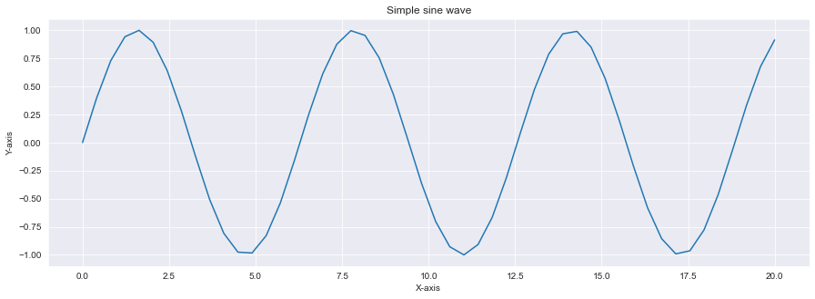

```python
x = np.linspace(0, 20) # Creates a linearly spaced vector from x=0 to x=20
y = np.sin(x) # Calculates the sin of x for the y axis
plt.plot(x, y)
plt.title("Simple sine wave")
plt.xlabel("X-axis")
plt.ylabel("Y-axis")
plt.show()
```

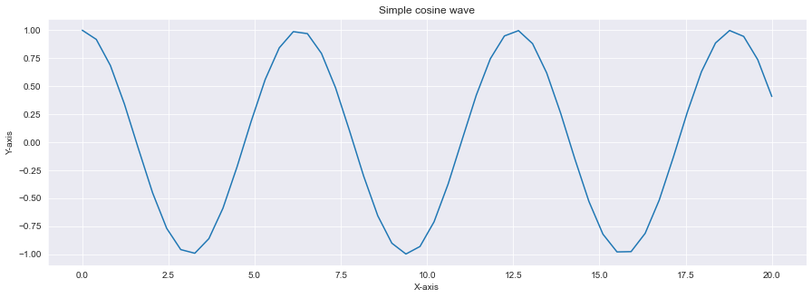

```python
x = np.linspace(0, 20) # Creates a linearly spaced vector from x=0 to x=20
y = np.cos(x) # Calculates the cos of x for the y axis
plt.plot(x, y)
plt.title("Simple cosine wave")
plt.xlabel("X-axis")
plt.ylabel("Y-axis")
plt.show()
```

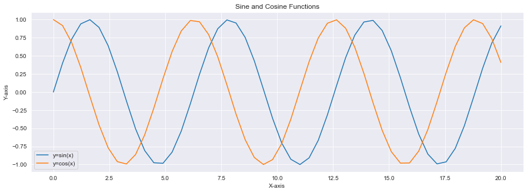

```python
plt.plot(x, np.sin(x), label='y=sin(x)')
plt.plot(x, np.cos(x), label='y=cos(x)')
plt.title('Sine and Cosine Functions')
plt.xlabel("X-axis")
plt.ylabel("Y-axis")
# Assigns a color to each plot along with it's corresponding label name to display in a legend.
plt.legend()
plt.show()
#You can plot multiple functions on the same graph by calling plot multiple times in the same cell
    #the labels in the plot calls and the plt.legend() assign unique colors to each graph
```

## Subplots

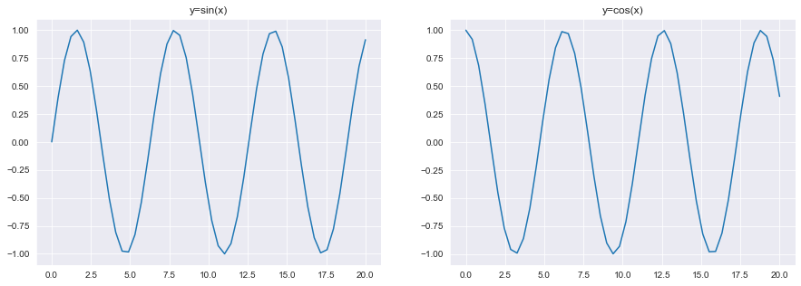

```python
# one figure object with 1x2=2 axes
fig, axes = plt.subplots(nrows=1, ncols=2)

# plotting sin(x) in axes[0]. left image, or 1st element/axis in the axes array.
axes[0].plot(x, np.sin(x))
# setting the title of axes[0] to be y=sin(x)
axes[0].set_title('y=sin(x)')

# plotting cos(x) in axes[1]. right image, or 2nd element/axis in the axes array.
axes[1].plot(x, np.cos(x))
# setting the title of axes[1] to be y=cos(x)
axes[1].set_title('y=cos(x)')

plt.show()
```

[output not shown]

[figure not shown]

```python
# one figure object with 1x2=2 axes
axes = plt.subplots(nrows=2, ncols=3)

# plotting sin(x) in axes[0]. left image, or 1st element/axis in the axes array.
axes[0,0].plot(x, np.sin(x))
# setting the title of axes[0] to be y=sin(x)
axes[0,0].set_title('y=sin(x)')

# plotting cos(x) in axes[1]. right image, or 2nd element/axis in the axes array.
axes[1,1].plot(x, np.cos(x))
# setting the title of axes[1] to be y=cos(x)
axes[1,1].set_title('y=cos(x)')

plt.show()
```

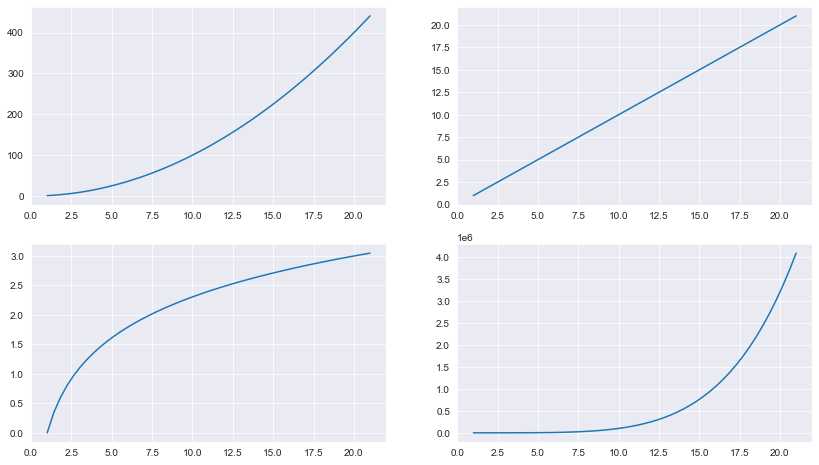

```python
x = np.linspace(1, 21)

fig, axes = plt.subplots(nrows=2, ncols=2, figsize=(14, 8))

axes[0][0].plot(x, x**2)
axes[0][1].plot(x, x)
axes[1][0].plot(x, np.log(x))
axes[1][1].plot(x, x**5)

plt.show()
```

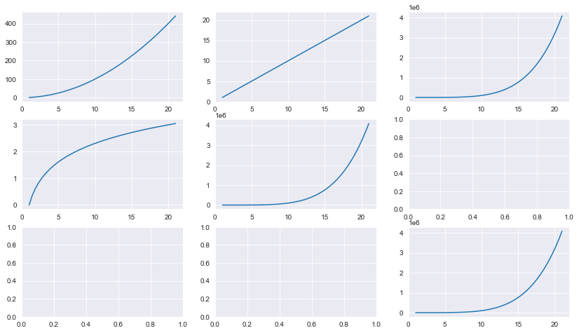

```python
x = np.linspace(1, 21)

fig, axes = plt.subplots(nrows=3, ncols=3, figsize=(14, 8))

axes[0][0].plot(x, x**2)
axes[0][1].plot(x, x)
axes[1][0].plot(x, np.log(x))
axes[1][1].plot(x, x**5)
axes[0][2].plot(x, x**5)
axes[2][2].plot(x, x**5)

plt.show()
```

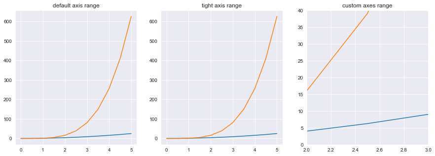

```python
x = np.linspace(0, 5, 11)

fig, axes = plt.subplots(nrows=1, ncols=3)

# we can also plot multiple graphs using plt.plot(x1, y1, x2, y2).
axes[0].plot(x, x**2, x, x**4)
axes[0].set_title('default axis range')

axes[1].plot(x, x**2, x, x**4)
# tight happens to be the same here, but this will come in handy when you want to automatically align axes in a
# fitted manner.
axes[1].axis('tight')
axes[1].set_title('tight axis range')

# notice the zoom in that happened.
axes[2].plot(x, x**2, x, x**4)
axes[2].set_ylim([0, 40])
axes[2].set_xlim([2, 3])
axes[2].set_title("custom axes range");

plt.show()
```

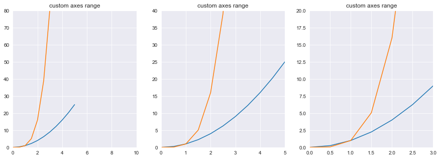

```python
x = np.linspace(0, 5, 11)

fig, axes = plt.subplots(nrows=1, ncols=3)

axes[0].plot(x, x**2, x, x**4)
axes[0].set_ylim([0, 80])
axes[0].set_xlim([0, 10])
axes[0].set_title("custom axes range");

axes[1].plot(x, x**2, x, x**4)
axes[1].set_ylim([0, 40])
axes[1].set_xlim([0, 5])
axes[1].set_title("custom axes range");

# notice the zoom in that happened.
axes[2].plot(x, x**2, x, x**4)
axes[2].set_ylim([0, 20])
axes[2].set_xlim([0, 3])
axes[2].set_title("custom axes range");

plt.show()
```

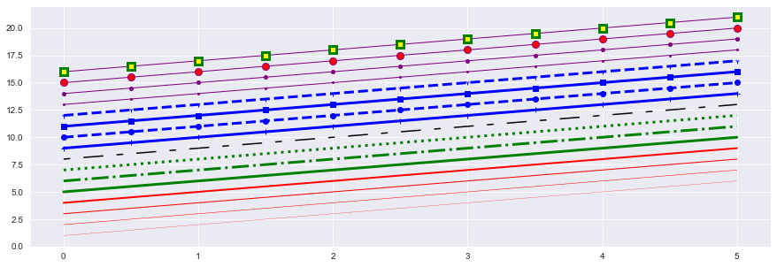

```python
x = np.linspace(0, 5, 11)

plt.plot(x, x+1, color="red", linewidth=0.25)
plt.plot(x, x+2, color="red", linewidth=0.50)
plt.plot(x, x+3, color="red", linewidth=1.00)
plt.plot(x, x+4, color="red", linewidth=2.00)

# possible linestype options ‘-‘, ‘–’, ‘-.’, ‘:’, ‘steps’
plt.plot(x, x+5, color="green", lw=3, linestyle='-')
plt.plot(x, x+6, color="green", lw=3, ls='-.')
plt.plot(x, x+7, color="green", lw=3, ls=':')

# custom dash (not something we'll do often)
line, = plt.plot(x, x+8, color="black", lw=1.50)
line.set_dashes([5, 10, 15, 10]) # format: line length, space length, ...

# possible marker symbols: marker = '+', 'o', '*', 's', ',', '.', '1', '2', '3', '4', ...
plt.plot(x, x+ 9, color="blue", lw=3, ls='-', marker='+')
plt.plot(x, x+10, color="blue", lw=3, ls='--', marker='o')
plt.plot(x, x+11, color="blue", lw=3, ls='-', marker='s')
plt.plot(x, x+12, color="blue", lw=3, ls='--', marker='1')

# marker size and color
plt.plot(x, x+13, color="purple", lw=1, ls='-', marker='o', markersize=2)
plt.plot(x, x+14, color="purple", lw=1, ls='-', marker='o', markersize=4)
plt.plot(x, x+15, color="purple", lw=1, ls='-', marker='o', markersize=8, markerfacecolor="red")
plt.plot(x, x+16, color="purple", lw=1, ls='-', marker='s', markersize=8,
        markerfacecolor="yellow", markeredgewidth=3, markeredgecolor="green");

#This is an example of all the different colors and styles of lines
```

[output not shown]

[output cut: 24 more lines]

[output not shown]

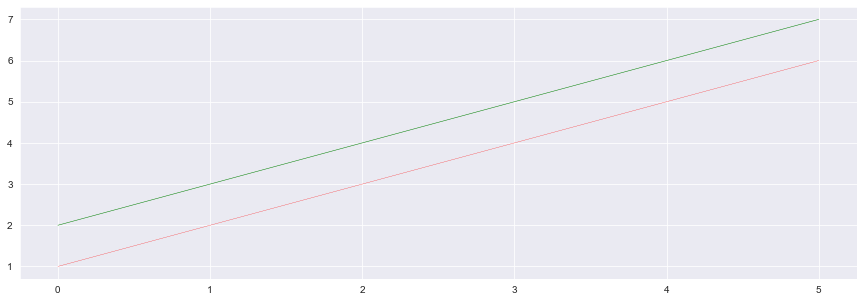

```python
x = np.linspace(0, 5, 11)

plt.plot(x, x+1, color="red", linewidth=0.25)
plt.plot(x, x+2, color="green", linewidth=0.50)
plt.plot(x, x+3, color="blue", linewidth=10.00, ls=":-")
plt.plot(x, x+4, color="purple", linewidth=2.00)
```

# Plotting Pandas Columns

```python
pokemon_df = pd.read_csv(filepath_or_buffer='Pokemon.csv')
pokemon_df.head()
```

|  | # | Name | Type 1 | Type 2 | Total | HP | Attack | Defense | Sp. Atk | Sp. Def | Speed | Generation | Legendary |
| --- | --- | --- | --- | --- | --- | --- | --- | --- | --- | --- | --- | --- | --- |
| 0 | 1 | Bulbasaur | Grass | Poison | 318 | 45 | 49 | 49 | 65 | 65 | 45 | 1 | False |
| 1 | 2 | Ivysaur | Grass | Poison | 405 | 60 | 62 | 63 | 80 | 80 | 60 | 1 | False |
| 2 | 3 | Venusaur | Grass | Poison | 525 | 80 | 82 | 83 | 100 | 100 | 80 | 1 | False |
| 3 | 3 | VenusaurMega Venusaur | Grass | Poison | 625 | 80 | 100 | 123 | 122 | 120 | 80 | 1 | False |
| 4 | 4 | Charmander | Fire | NaN | 309 | 39 | 52 | 43 | 60 | 50 | 65 | 1 | False |

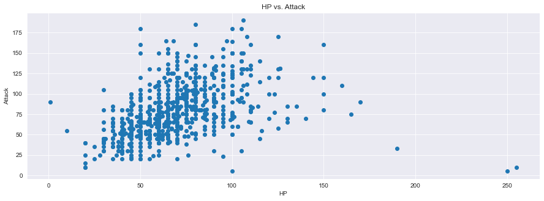

```python
plt.scatter(x=pokemon_df['HP'], y=pokemon_df['Attack'])
plt.xlabel('HP')
plt.ylabel('Attack')
plt.title('HP vs. Attack')
plt.show()
```

[output not shown]

[figure not shown]

```python
axes = plt.subplots(nrows=1, ncols=3)
axes[0].plt.scatter(x=pokemon_df['HP'], y=pokemon_df['Attack'])
axes[0].xlabel('HP')
axes[0].ylabel('Attack')
axes[0].title('HP vs. Attack')
plt.show()
```

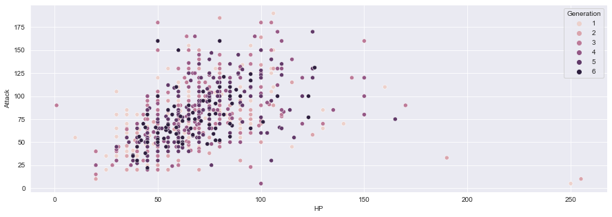

```python
sns.scatterplot(x=pokemon_df['HP'], y=pokemon_df['Attack'], hue='Generation', data=pokemon_df)
plt.show()
```

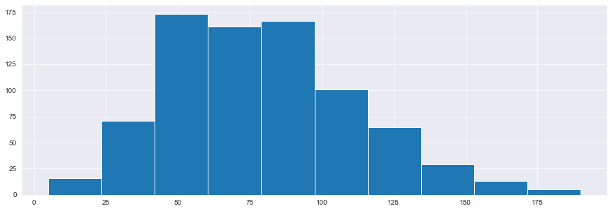

```python
plt.hist(x=pokemon_df['Attack'])
plt.show()
```

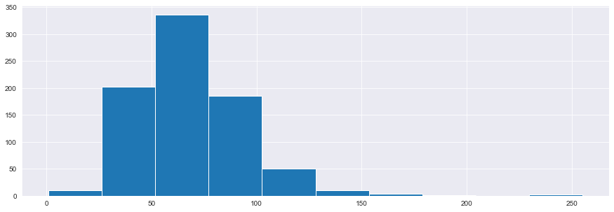

```python
plt.hist(x=pokemon_df['HP'])
plt.show()
```

```python
pokemon_df['Type 1'].value_counts()
```

```
Water       112
Normal       98
Grass        70
Bug          69
Psychic      57
Fire         52
Electric     44
Rock         44
Dragon       32
Ground       32
Ghost        32
Dark         31
Poison       28
Steel        27
Fighting     27
Ice          24
Fairy        17
Flying        4
Name: Type 1, dtype: int64
```

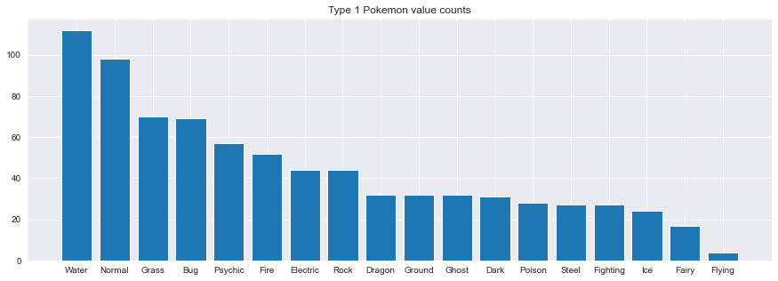

```python
# collect index names (left side of .value_counts())
type_1_names = pokemon_df['Type 1'].value_counts().index
# collect corresponding value counts (right side of .value_counts())
type_1_values = pokemon_df['Type 1'].value_counts().values
# plt.bar(x, y)
plt.bar(type_1_names, type_1_values)
plt.title('Type 1 Pokemon value counts')
plt.show()
```

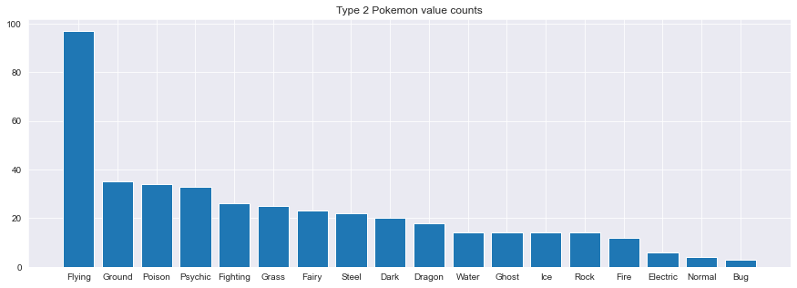

```python
# collect index names (left side of .value_counts())
type_2_names = pokemon_df['Type 2'].value_counts().index
# collect corresponding value counts (right side of .value_counts())
type_2_values = pokemon_df['Type 2'].value_counts().values
# plt.bar(x, y)
plt.bar(type_2_names, type_2_values)
plt.title('Type 2 Pokemon value counts')
plt.show()
```

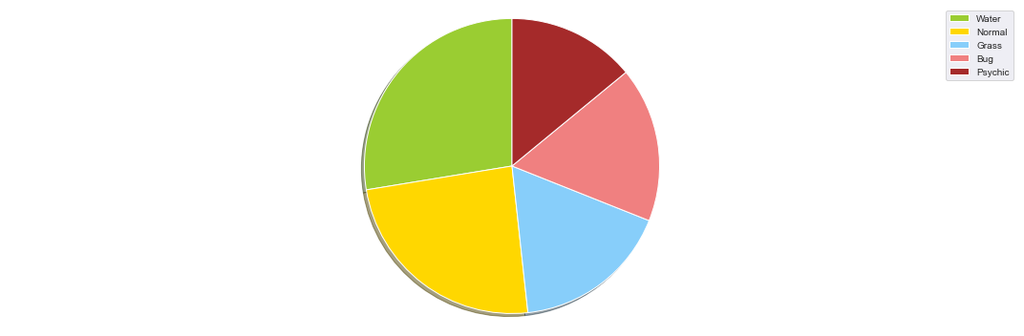

```python
# colors we'll use for each patch/wedge
colors = ['yellowgreen', 'gold', 'lightskyblue', 'lightcoral','brown']
patches, texts = plt.pie(type_1_values[:5], colors=colors, shadow=True, startangle=90)
plt.legend(patches, type_1_names[:5])
# will center our pie chart, but not necessary
plt.axis('equal')
plt.tight_layout()
plt.show()
```

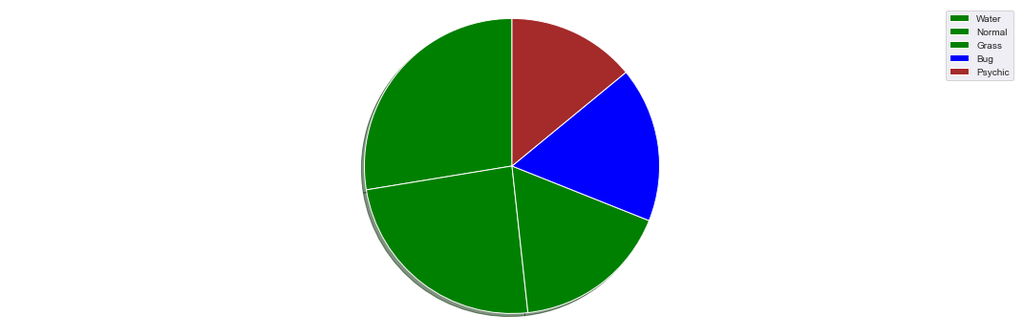

```python
# colors we'll use for each patch/wedge
colors = ['green', 'green', 'green', 'blue','brown']
patches, texts = plt.pie(type_1_values[:5], colors=colors, shadow=True, startangle=90)
plt.legend(patches, type_1_names[:5])
# will center our pie chart, but not necessary
plt.axis('equal')
plt.tight_layout()
plt.show()
```

```python
x = pokemon_df['Name'][:4]
y1 = pokemon_df['HP'][:4]
y2 = pokemon_df['Attack'][:4]
y3 = pokemon_df['Defense'][:4]
```

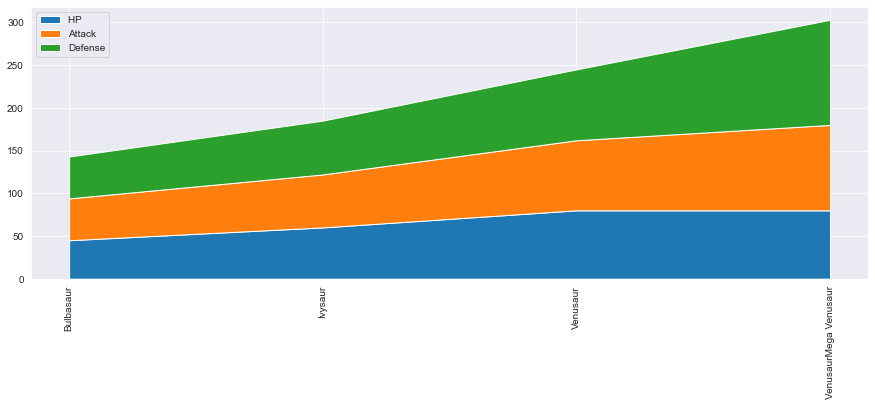

```python
labels = ["HP ", "Attack", "Defense"]

plt.stackplot(x, y1, y2, y3)
plt.legend(loc='upper left', labels=labels)
# rotates the xlabels to appear vertical rather than horizontal by default.
plt.xticks(rotation=90)
plt.show()
```

[figure not shown]

```python
x = pokemon_df['Sp. Atk'][:4]
y1 = pokemon_df['Sp. Def'][:4]
y2 = pokemon_df['Speed'][:4]

labels = ["HP ", "Attack", "Defense"]

plt.stackplot(x, y1, y2)
plt.legend(loc='upper left', labels=labels)
# rotates the xlabels to appear vertical rather than horizontal by default.
plt.xticks(rotation=90)
plt.show()
```

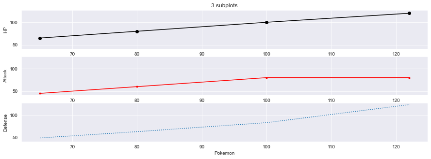

```python
# Create 3 subplots sharing y axis
fig, axes = plt.subplots(nrows=3, ncols=1, sharey=True)

# 'ko-, r.-, and : are just line styles and optional.'
# notice how you can also set multiple things together in one single command rather than
# creating separate .set_title, .set_ylabel, .set_xlabel, etc. commands like we were doing earlier.
axes[0].plot(x, y1, 'ko-')
axes[0].set(title='3 subplots', ylabel='HP')

axes[1].plot(x, y2, 'r.-')
axes[1].set(xlabel='Pokemon', ylabel='Attack')

axes[2].plot(x, y3, ':')
axes[2].set(xlabel='Pokemon', ylabel='Defense')

plt.show()
```

[figure not shown]

```python
# Create 3 subplots sharing y axis
fig, axes = plt.subplots(nrows=5, ncols=1, sharey=True)

# 'ko-, r.-, and : are just line styles and optional.'
# notice how you can also set multiple things together in one single command rather than
# creating separate .set_title, .set_ylabel, .set_xlabel, etc. commands like we were doing earlier.
axes[0].plot(x, y1, 'ko-')
axes[0].set(title='3 subplots', ylabel='HP')

axes[1].plot(x, y2, 'r.-')
axes[1].set(xlabel='Pokemon', ylabel='Attack')

axes[2].plot(x, y3, ':')
axes[2].set(xlabel='Pokemon', ylabel='Defense')

axes[3].plot(x, y1, 'b-')
axes[3].set(title='3 subplots', ylabel='Sp. Atk')

axes[4].plot(x, y2, 'g.-')
axes[4].set(xlabel='Pokemon', ylabel='Speed')

plt.show()
```

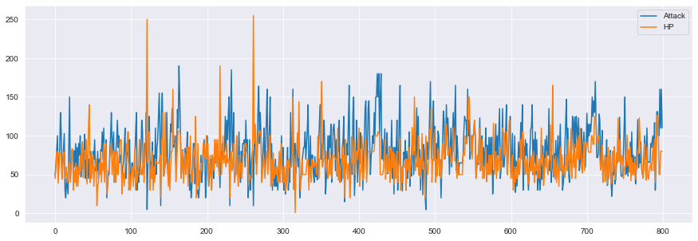

```python
plt.plot(pokemon_df['Attack'], label='Attack')
plt.plot(pokemon_df['HP'], label='HP')
plt.legend()
plt.show()
```

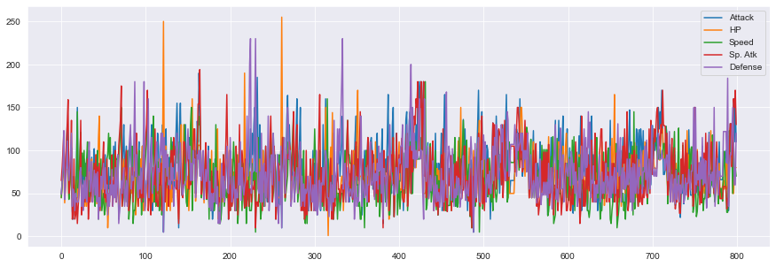

```python
plt.plot(pokemon_df['Attack'], label='Attack')
plt.plot(pokemon_df['HP'], label='HP')
plt.plot(pokemon_df['Speed'], label='Speed')
plt.plot(pokemon_df['Sp. Atk'], label='Sp. Atk')
plt.plot(pokemon_df['Defense'], label='Defense')
plt.legend()
plt.show()
```

```python
pokemon_df[['HP', 'Attack', 'Defense','Sp. Atk', 'Sp. Def', 'Speed']].corr()
```

|  | HP | Attack | Defense | Sp. Atk | Sp. Def | Speed |
| --- | --- | --- | --- | --- | --- | --- |
| HP | 1.000000 | 0.422386 | 0.239622 | 0.362380 | 0.378718 | 0.175952 |
| Attack | 0.422386 | 1.000000 | 0.438687 | 0.396362 | 0.263990 | 0.381240 |
| Defense | 0.239622 | 0.438687 | 1.000000 | 0.223549 | 0.510747 | 0.015227 |
| Sp. Atk | 0.362380 | 0.396362 | 0.223549 | 1.000000 | 0.506121 | 0.473018 |
| Sp. Def | 0.378718 | 0.263990 | 0.510747 | 0.506121 | 1.000000 | 0.259133 |
| Speed | 0.175952 | 0.381240 | 0.015227 | 0.473018 | 0.259133 | 1.000000 |

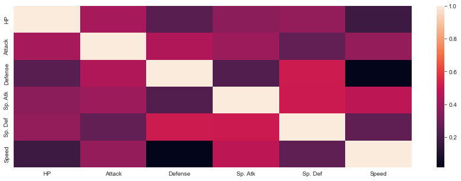

```python
sns.heatmap(pokemon_df[['HP', 'Attack', 'Defense','Sp. Atk', 'Sp. Def', 'Speed']].corr())
plt.show()
```